# World Happiness Report

## 가설 수립하기

### 상관계수에 대하여

- -1에 가까운 값이 얻어지면 : 누가 봐도 매우 강력한 음(-)의 상관. 오히려 너무 확고하기 때문에 사회과학 데이터일 경우 데이터를 조작한 게 아닌가 의심할 정도이다. 물론 이건 사회과학 얘기고 순수학문에 가까운 분야일수록 요구되는 상관관계는 높은 편.
- -0.5 정도의 값이 얻어지면 : 강력한 음(-)의 상관. 연구자는 변인 x 가 증가하면 변인 y 가 감소한다고 자신 있게 말할 수 있다.
- -0.2 정도의 값이 얻어지면 : 음(-)의 상관이긴 한데 너무 약해서 모호하다. 상관관계가 없다고는 할 수 없지만 좀 더 의심해 봐야 한다.
- 0 정도의 값이 얻어지면 : 대부분의 경우, 상관관계가 있을거라고 간주되지 않는다. 다른 후속 연구들을 통해 뒤집어질지는 모르지만 일단은 회의적이다. 하지만 무조건적으로 그런건 아니라 2차 방정식 그래프와 비슷한 모양이 될 경우 상관관계는 있으나 상관계수는 0에 가깝게 나온다.
- 0.2 정도의 값이 얻어지면 : 너무 약해서 의심스러운 양(+)의 상관. 이것만으로는 상관관계에 대해 아주 장담할 수는 없다. 하지만 사회과학에선 매우 큰 상관관계가 있는 것으로 간주한다.
- 0.5 정도의 값이 얻어지면 : 강력한 양(+)의 상관. 변인 x 가 증가하면 변인 y 가 증가한다는 주장은 이제 통계적으로 지지받고 있다.
- 1에 가까운 값이 얻어지면 : 이상할 정도로 강력한 양(+)의 상관. 위와 마찬가지로, 이렇게까지 확고한 상관관계는 오히려 쉽게 찾아보기 어렵다.

일반적으로  
r이 -1.0과 -0.7 사이이면, 강한 음적 선형관계, r이 -0.7과 -0.3 사이이면, 뚜렷한 음적 선형관계,  
r이 -0.3과 -0.1 사이이면, 약한 음적 선형관계,  
r이 -0.1과 +0.1 사이이면, 거의 무시될 수 있는 선형관계,  
r이 +0.1과 +0.3 사이이면, 약한 양적 선형관계,  
r이 +0.3과 +0.7 사이이면, 뚜렷한 양적 선형관계,  
r이 +0.7과 +1.0 사이이면, 강한 양적 선형관계  
로 해석한다.

### 상관계수 확인해보기

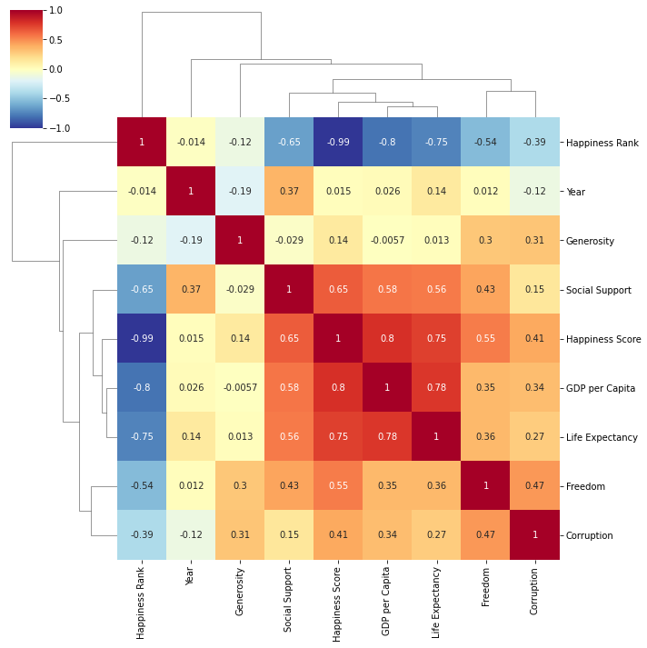

|  | Happiness Rank | Happiness Score | GDP per Capita | Social Support | Life Expectancy | Freedom | Corruption | Generosity | Year |
| --- | --- | --- | --- | --- | --- | --- | --- | --- | --- |
| Happiness Rank | 1.000000 | -0.992205 | -0.802026 | -0.646295 | -0.748683 | -0.538112 | -0.387597 | -0.119463 | -0.014137 |
| Happiness Score | -0.992205 | 1.000000 | 0.797339 | 0.650595 | 0.747745 | 0.550108 | 0.412705 | 0.139592 | 0.014665 |
| GDP per Capita | -0.802026 | 0.797339 | 1.000000 | 0.575385 | 0.779341 | 0.353443 | 0.341236 | -0.005723 | 0.025971 |
| Social Support | -0.646295 | 0.650595 | 0.575385 | 1.000000 | 0.562217 | 0.427273 | 0.148739 | -0.029177 | 0.372966 |
| Life Expectancy | -0.748683 | 0.747745 | 0.779341 | 0.562217 | 1.000000 | 0.355520 | 0.274275 | 0.013498 | 0.136038 |
| Freedom | -0.538112 | 0.550108 | 0.353443 | 0.427273 | 0.355520 | 1.000000 | 0.465758 | 0.302158 | 0.011839 |
| Corruption | -0.387597 | 0.412705 | 0.341236 | 0.148739 | 0.274275 | 0.465758 | 1.000000 | 0.310106 | -0.120543 |
| Generosity | -0.119463 | 0.139592 | -0.005723 | -0.029177 | 0.013498 | 0.302158 | 0.310106 | 1.000000 | -0.190227 |
| Year | -0.014137 | 0.014665 | 0.025971 | 0.372966 | 0.136038 | 0.011839 | -0.120543 | -0.190227 | 1.000000 |

이제 깔끔하게 2015~20019년도를 합쳐서 column간의 상관관계를 파악할 수 있다. -1, 1에 가까운 이상할 정도로 강력한 상관관계를 제외하고, 어떤 요소들이 행복에 기여하는지 알아보자. Happiness Score가 높을수록 Happiness Rank는 낮아진다. Happiness Score와 Rank는 같은 의미를 갖는 column이기 때문에, 여기서는 "행복"의 기준을 Happiness Score을 기준으로 하겠다.